# Data Challenge 1: Dairy Cow Visualizations

Ziyan Hu

Due 5:59pm on September 27, 2023

link to the github: https://github.com/freyahu2000/Data-Science-1

```r
# load in the required libraries
library(readr)
library(tidyverse)
library(RColorBrewer)

# read the data
state_milk_production <- read_csv("https://raw.githubusercontent.com/rfordatascience/tidytuesday/master/data/2019/2019-01-29/state_milk_production.csv",show_col_types = FALSE)
clean_cheese <- read_csv("https://raw.githubusercontent.com/rfordatascience/tidytuesday/master/data/2019/2019-01-29/clean_cheese.csv",show_col_types = FALSE)
fluid_milk_sales <- read_csv("https://raw.githubusercontent.com/rfordatascience/tidytuesday/master/data/2019/2019-01-29/fluid_milk_sales.csv",show_col_types = FALSE)
milk_products_facts <- read_csv("https://raw.githubusercontent.com/rfordatascience/tidytuesday/master/data/2019/2019-01-29/milk_products_facts.csv",show_col_types = FALSE)
milkcow_facts <- read_csv("https://raw.githubusercontent.com/rfordatascience/tidytuesday/master/data/2019/2019-01-29/milkcow_facts.csv",show_col_types = FALSE)

# disable scientific notation
options(scipen = 999)
```

### Figure 1

Make a scatter plot showing the milk production in pounds versus the average number of milk cows using `milkcow_facts`. Write a caption for this plot.

- The x-axis will be the number of milk cows (in millions) and the y-axis will be milk production (in millions of pounds)
- Color the plot using a continuous variable of years
- Label the axes (do not use the variable name)
- Add a title for the plot
- Label the legend (do not use the variable name)

#### Solution

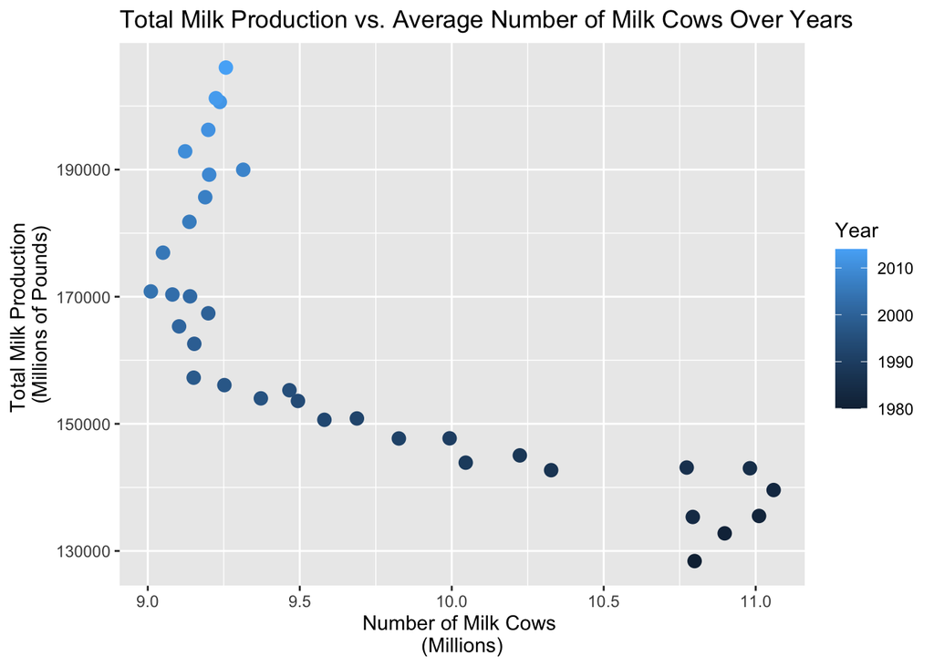

```r
# plot the milk production in pounds versus the average number of milk cow
milkcow_facts %>%
  ggplot(aes(x = avg_milk_cow_number/10^6, y = milk_production_lbs/10^6, color = year)) + # divide by 1 milion
  geom_point(size = 3) + # make scatter plot
  labs(x = "Number of Milk Cows \n(Millions)", # relabel y-axis
       y = "Total Milk Production \n(Millions of Pounds)", # relabel x-axis
       title = "Total Milk Production vs. Average Number of Milk Cows Over Years", # add a title
       color = "Year") + # relabel the legend
  scale_fill_continuous()
```

### Figure 2

Examine the milk total milk production in each region over time using `state_milk_production`. We will plot line plots for the milk production versus the year faceted by region. Write a caption for this plot.

- First, find the total production of milk each year by region (hint: use `summarise()` to find this)
- The x-axis will be time and the y-axis will be total milk produced (in millions of pounds) in the region that year
- Make line plots and color each line a different color
- Facet the plot by region
- Label the axes (do not use the variable name)
- Add a title for the plot
- Remove the legend from the plot

#### Solution

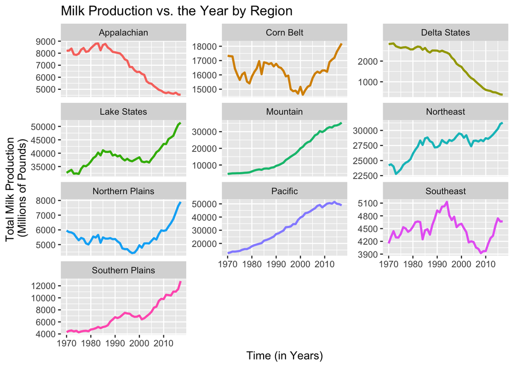

```r
# find the total production of milk by region by summarise
region_milk_production <- state_milk_production %>%
  group_by(year,region) %>%
  summarise(total_production_by_region = sum(milk_produced),.groups = "drop")

# plot the total milk production vs. year by region
region_milk_production %>%
  ggplot(aes(x = year, y = total_production_by_region/10^6, color = region)) +  # divide by 1 million
  geom_line(lwd = 1) +  # add the line plot
  facet_wrap(~region, nrow = 4, scales = "free_y") +  # facet the plot by region
  labs(x = "Time (in Years)",
       y = "Total Milk Production \n(Millions of Pounds)",
       title = "Milk Production vs. the Year by Region") +  # label the axes and add a title
  theme(legend.position = "none")  # remove the legend
```

### Figure 3

Make a line plot showing the amount (in pounds) of each milk products sold over time using `fluid_milk_sales`. Write a caption for this plot.

- Do not include the category ‘Total Production’ in the plot
- The x-axis will be time and the y-axis will be pounds of product
- Each milk product will be a separate line on the plot
- A different color will be assigned for each milk product
- Make the plot on the log scale for better visualization
- Label the axes (do not use the variable name)
- Add a title for the plot
- Label the legend (do not use the variable name)

#### Solution

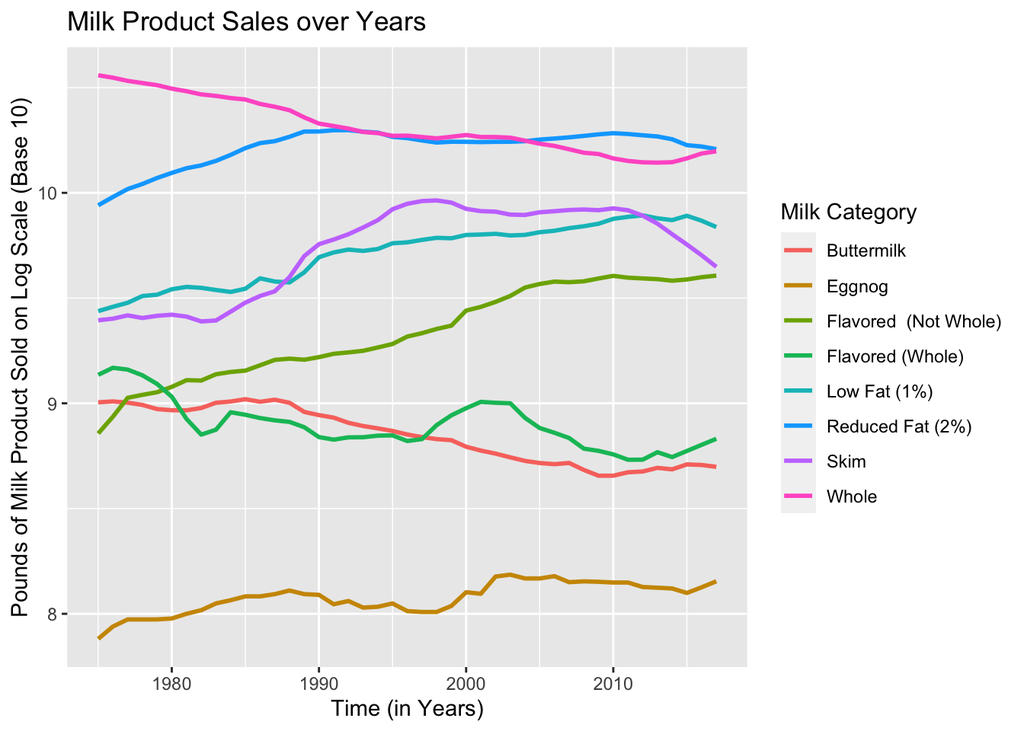

```r
# create new data frame
new_fluid_milk_sales <- fluid_milk_sales %>%
  filter(milk_type != "Total Production")  # delete the category 'Total Production'

# plot the milk product sales over time
new_fluid_milk_sales %>%
  ggplot(aes(x = year, y = log10(pounds), color = milk_type)) +  # make the plot on a log scale
  geom_line(lwd = 1) +  # add the line
  labs(x = "Time (in Years)", y = "Pounds of Milk Product Sold on Log Scale (Base 10)", title = "Milk Product Sales over Years", color = "Milk Category")  # label the axes and add a title
```

### Figure 4

Make a stacked bar plot of the different type of cheeses consumed over time using a long format version of `clean_cheese` that you create. Write a caption for this plot.

Data wrangling (hint: create a new dataframe called `clean_cheese_long`):

- Remove all of the total cheese variables (we do not want these in the plot)
- Change the `clean_cheese` data to long format using `pivot_longer()`
- Make sure all of the cheese categories are capitalized

Plotting:

- The x-axis will be time and the y-axis will be pounds of cheese
- Color the stacked bar plot by the different types of cheese
- Label the axes (do not use the variable name)
- Add a title for the plot
- Change the color of the plot using a palette from RColorBrewer (note that not all palettes will have enough colors for the plot)

#### Solution

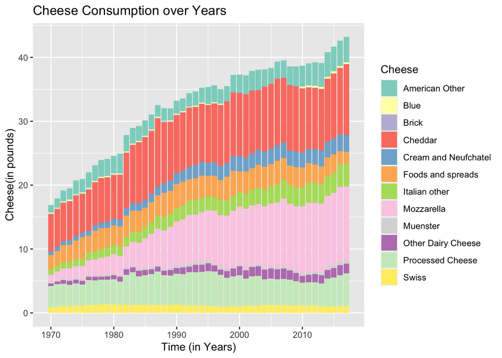

```r
# create a new data frame
clean_cheeese_long <- clean_cheese %>%
  select(-matches("Total")) %>%  # remove total cheese variables
  pivot_longer(-Year,
               names_to = "Cheese",
               values_to = "Pounds")  # change the data to long format

# plot
clean_cheeese_long %>%
  ggplot(aes(x = Year, y = Pounds, fill = Cheese)) +  # color by cheese
  geom_bar(stat = "identity") +  # add the bar plot
  labs(title = "Cheese Consumption over Years",
       x = "Time (in Years)",
       y = "Cheese(in pounds)") +  # relabel the axes and add a title
  scale_fill_brewer(palette = "Set3")  # change the color
```

Figure 4 displays U.S. cheese consumption from 1970 to 2017 using stacked bar charts. Total pounds of cheese consumed increased over time, led by significant gains in mozzarella. Consumption of cheddar, Italian other, American other and cream & neufchatel cheese grew more slowly, while foods and spread cheese declined.

### Figure 5

Time to be creative! Make an original figure using the data. Join two of the dataframes together and use variables from both sides of the join to make this figure. This figure should tell a story and be easy to understand (just as the figures above are!). Change the colors of this plot from the default ggplot2 colors. Write a caption for this plot.

#### Solution

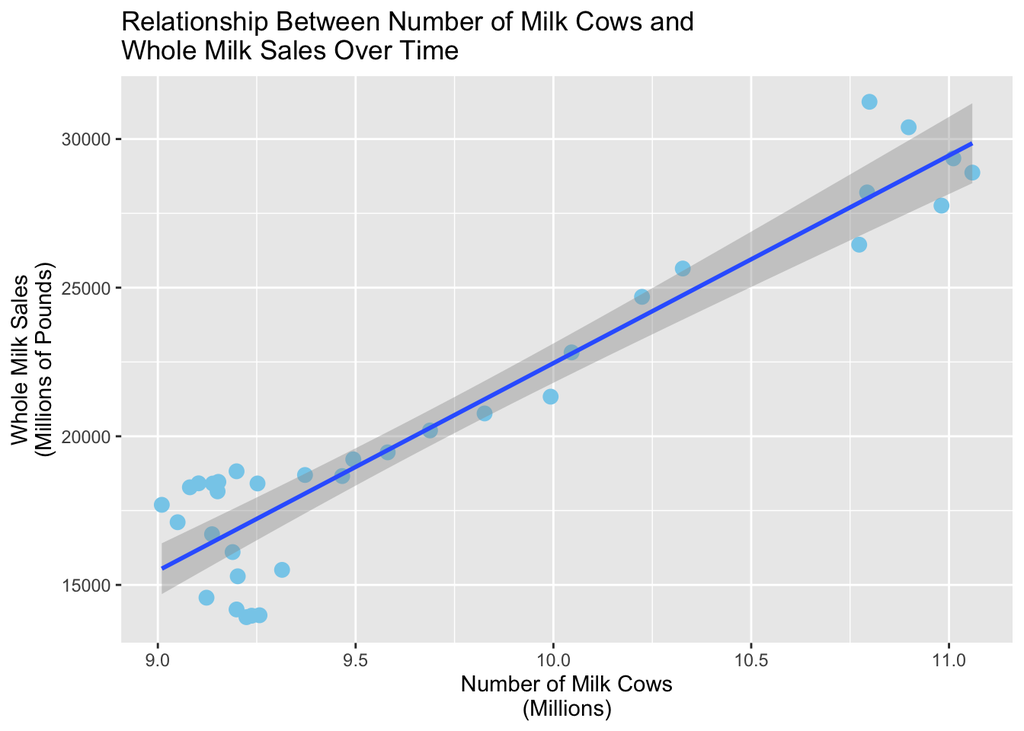

```r
# join milk_facts and fluid_milk_sales
milk_data <- milkcow_facts %>%
  left_join(fluid_milk_sales %>%
              filter(milk_type == "Whole"),
            by = "year")

# plot the figure
milk_data %>%
  ggplot(aes(x=avg_milk_cow_number/10^6, y = pounds/10^6)) +
  geom_point(size = 3, color = "skyblue") +  # change the color of default ggplot2 colors
  geom_smooth(method = "lm") + # add regression line
  labs(x = "Number of Milk Cows\n(Millions)",
       y = "Whole Milk Sales\n(Millions of Pounds)",
  title = "Relationship Between Number of Milk Cows and \nWhole Milk Sales Over Time")
```